# Heart Disease Prediction

Introduction: It is a well known fact that Heart Diseases are currently the leading cause of death across the globe. The development of a computational system that can predict the presence of heart diseases in patients will significantly reduce the mortality rates and substantially reduce the costs of healthcare. Machine learning is used accross many spheres around the world. Especially it is gaining more popularity in the healthcare industry. Machine learning can play an essential role in predicting presense or absence of a critical disease, for an instance, Heart disease, etc. If such information is predicted well in advance, can provide important insights to the doctors, who can then carry out the treatments of the patients accordingly and efficiently. The following R notebook demonstrates an exploratory data analysis of the popular Heart Disease UCI database. In addition to that, heart disease prediction is carried out using different approaches such as logistic regression, Random Forest and Neural Networks.

Dataset: The dataset used in the following R notebook can be found on “http://archive.ics.uci.edu/ml/datasets/heart+disease”. Each dataset(cleveland.data, hungarian.data, switzerland.data 7 long-beach-va.data) consisted of 76 attributes but it is recommended to use only 14 for our analysis. In this notebook classifiers were built using one combined dataset and the performance evaluation is carried out using cross-validation techniques.

Features:

1. Age: Age in years.
2. Gender: 1 = male, 0 = female
3. Cp: Chest Pain Type –> Value 1: Typical Angina, Value 2: Atypical Angina, Value 3: Non-Anginal Pain, Value 4: Asymptomatic
4. Trestbps: Resting Blood-Pressure (in mm Hg)
5. Chol: Serum Cholestrol (in mg/dl)
6. Fbs: Fasting Blood Sugar > 120 mg/dl –> 1 = true, 0 = Flase
7. Restecg: Resting Electro-cardio-Graph results –> Value 0: Normal, Value 1: Having ST-T wave abnormality, Value 2: showing probable or definite left ventricular hypertropy by Estes criteria
8. Thalach: Maximum heart rate achieved in beats per minute (bpm)
9. Exang: Exercise Induced Angina –> 1 = yes, 0 = no
10. Oldpeak: ST depression induced by exercise relative to rest
11. Slope: the slope of the peak exercise ST segment –> Value 1: Unsloping, Value 2: Flat, Value 3: Down-Sloping
12. Ca: number of major vessels (0-3) colored by fluoroscopy
13. Thal: 3 = normal; 6 = fixed defect; 7 = reversible defect
14. target: two classes and hence a binary classification problem.

Goal: To predict whether a person has a heart-disease or not.

```r
#Importing essential libraries
knitr::opts_chunk$set(echo = TRUE)
library(broom)
library(ggthemes)
library(caret)
```

```r
library(bindrcpp)
library(RColorBrewer)
library(caTools)
library(ggplot2)
library(GGally)
library(rpart.plot)
library(rattle)
library(dplyr)
library(nnet)
```

Reading the dataset and checking for missing entries

```r
heartDiseaseData<-read.csv("/home/maharsh/Desktop/DAV/heart-disease-uci/heart.csv")
#printing the head values
head(heartDiseaseData)
```

|  | age | sex | cp | trestbps | chol | fbs | restecg | thalach | exang | oldpeak | slope | ca | thal | target |
| --- | --- | --- | --- | --- | --- | --- | --- | --- | --- | --- | --- | --- | --- | --- |
| 1 | 52 | 1 | 0 | 125 | 212 | 0 | 1 | 168 | 0 | 1.0 | 2 | 2 | 3 | 0 |
| 2 | 53 | 1 | 0 | 140 | 203 | 1 | 0 | 155 | 1 | 3.1 | 0 | 0 | 3 | 0 |
| 3 | 70 | 1 | 0 | 145 | 174 | 0 | 1 | 125 | 1 | 2.6 | 0 | 0 | 3 | 0 |
| 4 | 61 | 1 | 0 | 148 | 203 | 0 | 1 | 161 | 0 | 0.0 | 2 | 1 | 3 | 0 |
| 5 | 62 | 0 | 0 | 138 | 294 | 1 | 1 | 106 | 0 | 1.9 | 1 | 3 | 2 | 0 |
| 6 | 58 | 0 | 0 | 100 | 248 | 0 | 0 | 122 | 0 | 1.0 | 1 | 0 | 2 | 1 |

```r
sum(is.na(heartDiseaseData))
```

```
## [1] 0
```

```r
colnames(heartDiseaseData)[1]<-"age"
str(heartDiseaseData)
```

```
## 'data.frame':    1025 obs. of  14 variables:
##  $ age     : int  52 53 70 61 62 58 58 55 46 54 ...
##  $ sex     : int  1 1 1 1 0 0 1 1 1 1 ...
##  $ cp      : int  0 0 0 0 0 0 0 0 0 0 ...
##  $ trestbps: int  125 140 145 148 138 100 114 160 120 122 ...
##  $ chol    : int  212 203 174 203 294 248 318 289 249 286 ...
##  $ fbs     : int  0 1 0 0 1 0 0 0 0 0 ...
##  $ restecg : int  1 0 1 1 1 0 2 0 0 0 ...
##  $ thalach : int  168 155 125 161 106 122 140 145 144 116 ...
##  $ exang   : int  0 1 1 0 0 0 0 1 0 1 ...
##  $ oldpeak : num  1 3.1 2.6 0 1.9 1 4.4 0.8 0.8 3.2 ...
##  $ slope   : int  2 0 0 2 1 1 0 1 2 1 ...
##  $ ca      : int  2 0 0 1 3 0 3 1 0 2 ...
##  $ thal    : int  3 3 3 3 2 2 1 3 3 2 ...
##  $ target  : int  0 0 0 0 0 1 0 0 0 0 ...
```

Data-Preprocessing

```r
#Factoring the features
#Target
heartDiseaseData$target<-as.factor(heartDiseaseData$target)
levels(heartDiseaseData$target)[levels(heartDiseaseData$target)==0] <- "Healthy"
levels(heartDiseaseData$target)[levels(heartDiseaseData$target)==1] <- "Heart Disease"
#Chest Pain
heartDiseaseData$cp<-as.factor(heartDiseaseData$cp)
levels(heartDiseaseData$cp)[levels(heartDiseaseData$cp)==0] <- "Chest Pain Type 0"
levels(heartDiseaseData$cp)[levels(heartDiseaseData$cp)==1] <- "Chest Pain Type 1"
levels(heartDiseaseData$cp)[levels(heartDiseaseData$cp)==2] <- "Chest Pain Type 2"
levels(heartDiseaseData$cp)[levels(heartDiseaseData$cp)==3] <- "Chest Pain Type 3"
#Sex
heartDiseaseData$sex<-as.factor(heartDiseaseData$sex)
levels(heartDiseaseData$sex)[levels(heartDiseaseData$sex)==0] <- "Female"
levels(heartDiseaseData$sex)[levels(heartDiseaseData$sex)==1] <- "Male"
#Thalassemia
heartDiseaseData$thal<-as.factor(heartDiseaseData$thal)
levels(heartDiseaseData$thal)[levels(heartDiseaseData$thal)==0] <- "No Thalassemia"
levels(heartDiseaseData$thal)[levels(heartDiseaseData$thal)==1] <- "Normal Thalassemia"
levels(heartDiseaseData$thal)[levels(heartDiseaseData$thal)==2] <- "Fixed Defect Thalassemia"
levels(heartDiseaseData$thal)[levels(heartDiseaseData$thal)==3] <- "Reversible Defect Thalassemia"
#Fasting Blood Sugar
heartDiseaseData$fbs<-as.factor(heartDiseaseData$fbs)
levels(heartDiseaseData$fbs)[levels(heartDiseaseData$fbs)==0] <- "Fasting Blood Sugar <= 120"
levels(heartDiseaseData$fbs)[levels(heartDiseaseData$fbs)==1] <- "Fasting Blood Sugar > 120"
#Exercise Induced Angina
heartDiseaseData$exang<-as.factor(heartDiseaseData$exang)
levels(heartDiseaseData$exang)[levels(heartDiseaseData$exang)==1] <- "Exercise Induced Angina"
levels(heartDiseaseData$exang)[levels(heartDiseaseData$exang)==0] <- "No Exercise Induced Angina"
#ECG
heartDiseaseData$restecg<-as.factor(heartDiseaseData$restecg)
levels(heartDiseaseData$restecg)[levels(heartDiseaseData$restecg)==0] <- "Rest ECG 0"
levels(heartDiseaseData$restecg)[levels(heartDiseaseData$restecg)==1] <- "Rest ECG 1"
levels(heartDiseaseData$restecg)[levels(heartDiseaseData$restecg)==2] <- "Rest ECG 2"
#ST Slope
heartDiseaseData$slope<-as.factor(heartDiseaseData$slope)
levels(heartDiseaseData$slope)[levels(heartDiseaseData$slope)==0] <- "Peak Excercise ST Slope 0"
levels(heartDiseaseData$slope)[levels(heartDiseaseData$slope)==1] <- "Peak Excercise ST Slope 1"
levels(heartDiseaseData$slope)[levels(heartDiseaseData$slope)==2] <- "Peak Excercise ST Slope 2"

str(heartDiseaseData)
```

```
## 'data.frame':    1025 obs. of  14 variables:
##  $ age     : int  52 53 70 61 62 58 58 55 46 54 ...
##  $ sex     : Factor w/ 2 levels "Female","Male": 2 2 2 2 1 1 2 2 2 2 ...
##  $ cp      : Factor w/ 4 levels "Chest Pain Type 0",..: 1 1 1 1 1 1 1 1 1 1 ...
##  $ trestbps: int  125 140 145 148 138 100 114 160 120 122 ...
##  $ chol    : int  212 203 174 203 294 248 318 289 249 286 ...
##  $ fbs     : Factor w/ 2 levels "Fasting Blood Sugar <= 120",..: 1 2 1 1 2 1 1 1 1 1 ...
##  $ restecg : Factor w/ 3 levels "Rest ECG 0","Rest ECG 1",..: 2 1 2 2 2 1 3 1 1 1 ...
##  $ thalach : int  168 155 125 161 106 122 140 145 144 116 ...
##  $ exang   : Factor w/ 2 levels "No Exercise Induced Angina",..: 1 2 2 1 1 1 1 2 1 2 ...
##  $ oldpeak : num  1 3.1 2.6 0 1.9 1 4.4 0.8 0.8 3.2 ...
##  $ slope   : Factor w/ 3 levels "Peak Excercise ST Slope 0",..: 3 1 1 3 2 2 1 2 3 2 ...
##  $ ca      : int  2 0 0 1 3 0 3 1 0 2 ...
##  $ thal    : Factor w/ 4 levels "No Thalassemia",..: 4 4 4 4 3 3 2 4 4 3 ...
##  $ target  : Factor w/ 2 levels "Healthy","Heart Disease": 1 1 1 1 1 2 1 1 1 1 ...
```

Checking for missing values

```r
sum(is.na(heartDiseaseData))
```

```
## [1] 0
```

Summary of the data

```r
summary(heartDiseaseData)
```

```
##       age            sex                      cp         trestbps
##  Min.   :29.00   Female:312   Chest Pain Type 0:497   Min.   : 94.0
##  1st Qu.:48.00   Male  :713   Chest Pain Type 1:167   1st Qu.:120.0
##  Median :56.00                Chest Pain Type 2:284   Median :130.0
##  Mean   :54.43                Chest Pain Type 3: 77   Mean   :131.6
##  3rd Qu.:61.00                                        3rd Qu.:140.0
##  Max.   :77.00                                        Max.   :200.0
##       chol                             fbs            restecg
##  Min.   :126   Fasting Blood Sugar <= 120:872   Rest ECG 0:497
##  1st Qu.:211   Fasting Blood Sugar > 120 :153   Rest ECG 1:513
##  Median :240                                    Rest ECG 2: 15
##  Mean   :246
##  3rd Qu.:275
##  Max.   :564
##     thalach                             exang        oldpeak
##  Min.   : 71.0   No Exercise Induced Angina:680   Min.   :0.000
##  1st Qu.:132.0   Exercise Induced Angina   :345   1st Qu.:0.000
##  Median :152.0                                    Median :0.800
##  Mean   :149.1                                    Mean   :1.072
##  3rd Qu.:166.0                                    3rd Qu.:1.800
##  Max.   :202.0                                    Max.   :6.200
##                        slope           ca
##  Peak Excercise ST Slope 0: 74   Min.   :0.0000
##  Peak Excercise ST Slope 1:482   1st Qu.:0.0000
##  Peak Excercise ST Slope 2:469   Median :0.0000
##                                  Mean   :0.7541
##                                  3rd Qu.:1.0000
##                                  Max.   :4.0000
##                             thal               target
##  No Thalassemia               :  7   Healthy      :499
##  Normal Thalassemia           : 64   Heart Disease:526
##  Fixed Defect Thalassemia     :544
##  Reversible Defect Thalassemia:410
##
##
```

Total number of observations of heathy people and people suffering from heart disease.

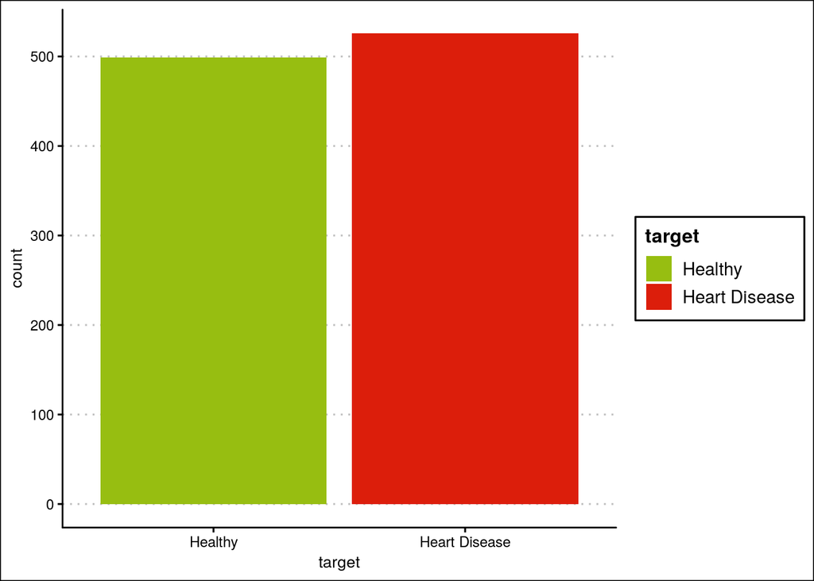

```r
ggplot(heartDiseaseData,aes(target, fill=target)) +
  geom_bar(stat="count") + theme_clean()  +
  scale_fill_manual(values=c("#97BE11","#DC1E0B"))
```

Heart diseases among females are higher as compared to males

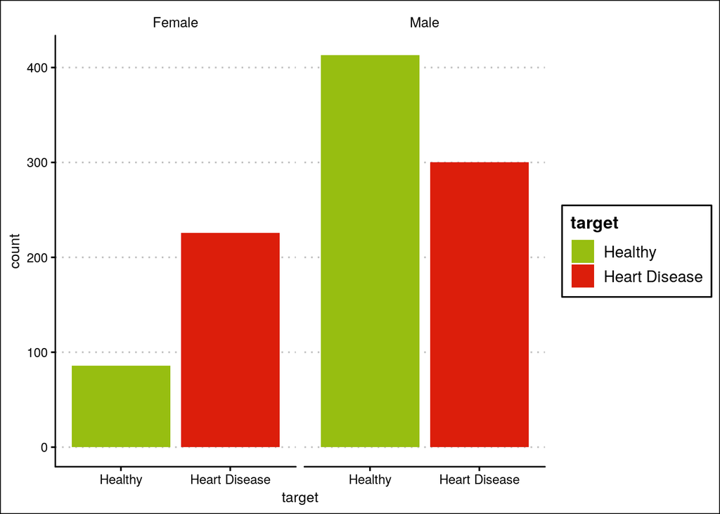

```r
ggplot(heartDiseaseData,aes(target, fill=target)) +
  geom_bar(stat="count") +
  facet_wrap(~sex, ncol=2,scale="fixed") +
  theme_clean() +
  scale_fill_manual(values=c("#97BE11","#DC1E0B"))
```

It can be observed that there is no major difference between the distributions of Rest ECG of healthy people and the ones exhibiting heart diseases.

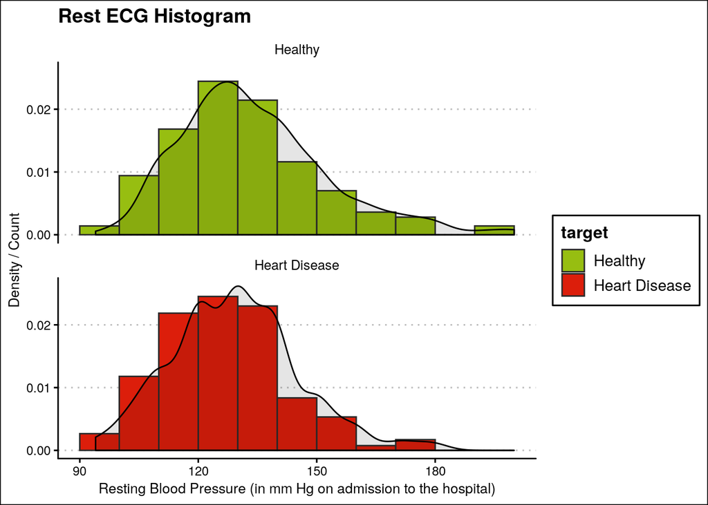

```r
ggplot(heartDiseaseData,aes(trestbps, fill=target)) +
  geom_histogram(aes(y=..density..),breaks=seq(90, 200, by=10), color="grey17") +
  geom_density(alpha=.1, fill="black") +
  facet_wrap(~target, ncol=1,scale="fixed") +
  theme_clean()  +
  scale_fill_manual(values=c("#97BE11","#DC1E0B")) +
  xlab("Resting Blood Pressure (in mm Hg on admission to the hospital)") +
  ylab("Density / Count") +
  ggtitle("Rest ECG Histogram")
```

It can be observed that heart disease is uniformly spread out across age. In addtion to that the median age for patients estimated was 56 with youngest and oldest being 29 and 77 respectively. It can be observed from the plots that the median age of the people exhibiting heart diseases is less than the healthy ones. Moreover, it can be observed that the distribution of patients exhibiting heart diseases is slighly skewed. Hence, we can use age as an predictive feature.

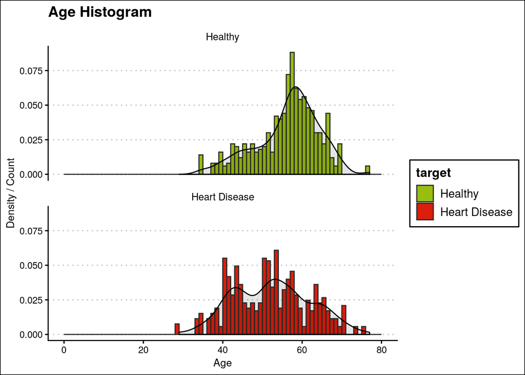

```r
ggplot(heartDiseaseData,aes(age, fill=target)) +
  geom_histogram(aes(y=..density..),breaks=seq(0, 80, by=1), color="grey17") +
  geom_density(alpha=.1, fill="black")+ facet_wrap(~target, ncol=1,scale="fixed") +
  theme_clean()  + scale_fill_manual(values=c("#97BE11","#DC1E0B"))+ xlab("Age") +
  ylab("Density / Count") +
  ggtitle("Age Histogram")
```

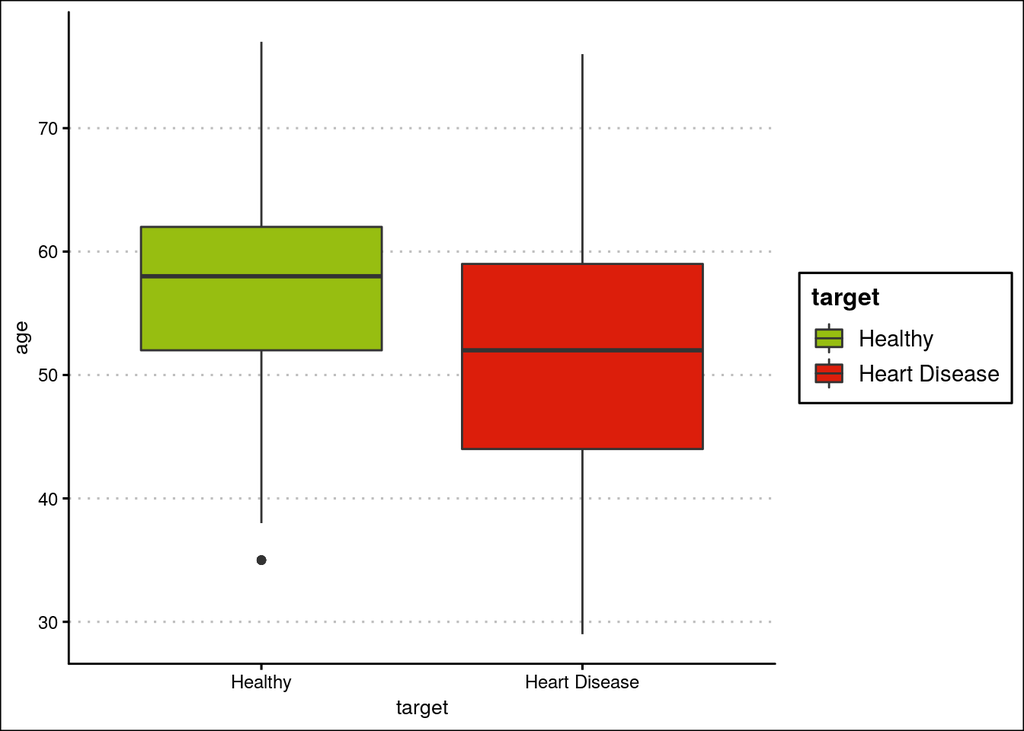

```r
ggplot(heartDiseaseData,aes(x=target, y=age, fill=target)) +
  geom_boxplot() +
  theme_clean() +
  scale_fill_manual(values=c("#97BE11","#DC1E0B"))
```

Additionally, People exhibiting heart diseases generally have higher maximum heart rates as compared to healthy people.

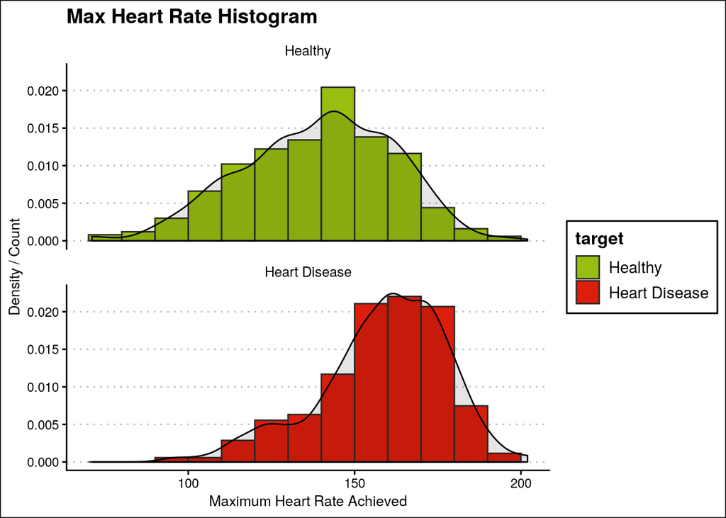

```r
ggplot(heartDiseaseData,aes(thalach, fill=target)) +
  geom_histogram(aes(y=..density..),breaks=seq(70, 205, by=10), color="grey17") +
  geom_density(alpha=.1, fill="black") +
  facet_wrap(~target, ncol=1,scale="fixed") +
  theme_clean() +
  scale_fill_manual(values=c("#97BE11","#DC1E0B")) +
  xlab("Maximum Heart Rate Achieved") +
  ylab("Density / Count") +
  ggtitle("Max Heart Rate Histogram")
```

Moroever, it can be observed here that majority of the people exhibiting heart diseases have their serum cholestrol in the range of 200 - 300 mg/dl

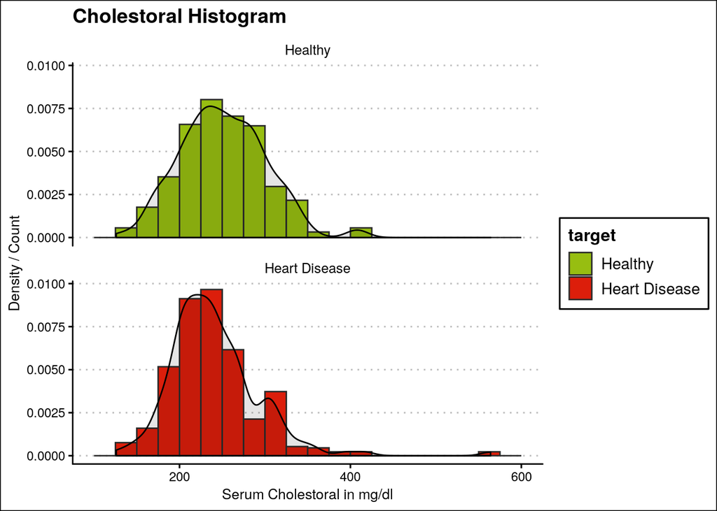

```r
ggplot(heartDiseaseData,aes(chol, fill=target)) +
  geom_histogram(aes(y=..density..),breaks=seq(100, 600, by=25), color="grey17") +
  geom_density(alpha=.1, fill="black") +
  facet_wrap(~target, ncol=1,scale="fixed") +
  theme_clean() +
  scale_fill_manual(values=c("#97BE11","#DC1E0B")) +
  xlab("Serum Cholestoral in mg/dl") +
  ylab("Density / Count") +
  ggtitle("Cholestoral Histogram")
```

Majority of heart diseased patients have ST-Depression of 0.1

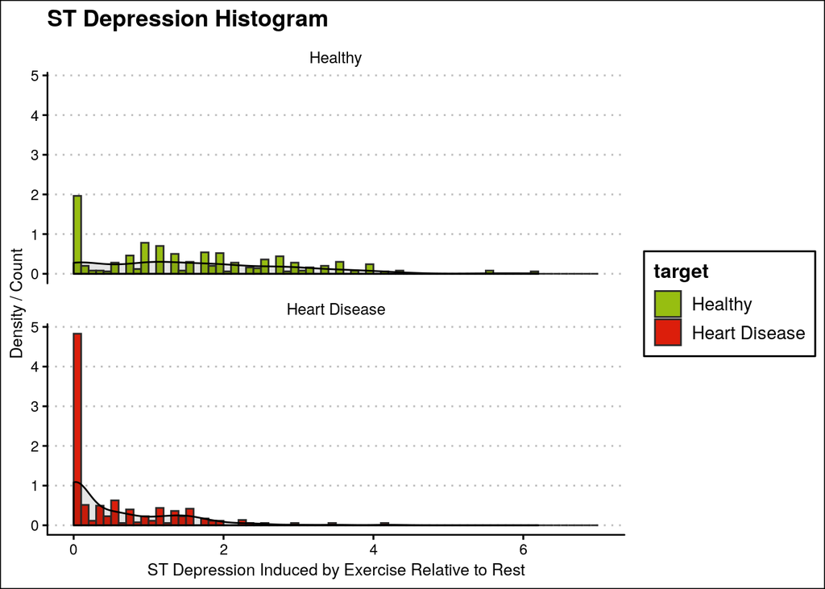

```r
ggplot(heartDiseaseData,aes(oldpeak, fill=target)) +
  geom_histogram(aes(y=..density..),breaks=seq(0, 7, by=0.1), color="grey17") +
  geom_density(alpha=.1, fill="black") +
  facet_wrap(~target, ncol=1,scale="fixed") +
  theme_clean() +
  scale_fill_manual(values=c("#97BE11","#DC1E0B")) +
  ggtitle("ST Depression Histogram") +
  xlab("ST Depression Induced by Exercise Relative to Rest") +
  ylab("Density / Count")
```

Most of the people who have 0-Major vessels are suffering from heart diseases

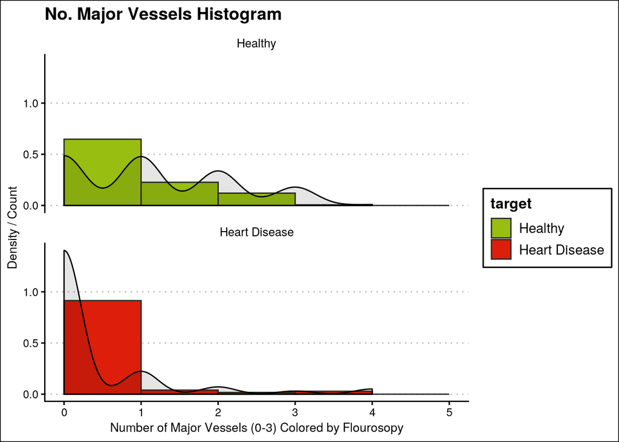

```r
ggplot(heartDiseaseData,aes(ca, fill=target)) +
  geom_histogram(aes(y=..density..),breaks=seq(0, 5, by=1), color="grey17") +
  geom_density(alpha=.1, fill="black") +
  facet_wrap(~target, ncol=1,scale="fixed") +
  theme_clean() +
  scale_fill_manual(values=c("#97BE11","#DC1E0B")) +
  ggtitle("No. Major Vessels Histogram") +
  xlab("Number of Major Vessels (0-3) Colored by Flourosopy") +
  ylab("Density / Count")
```

Majority of people suffering from heart diseases have chest pains of type 1 or 2.

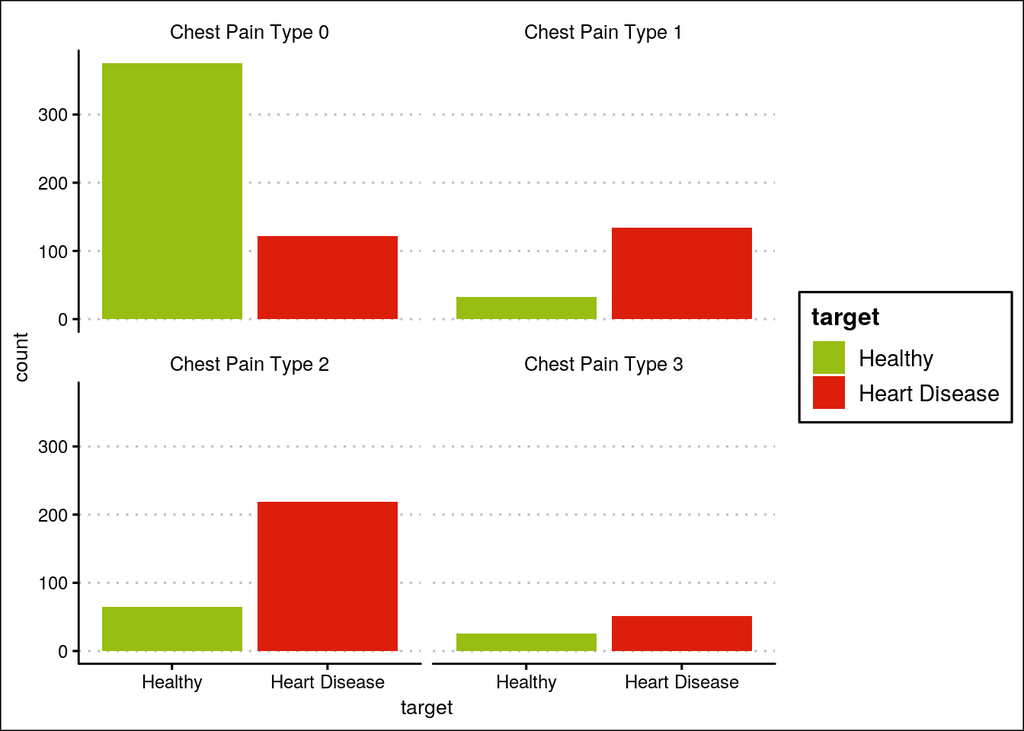

```r
ggplot(heartDiseaseData,aes(target, fill=target)) +
  geom_bar(stat="count") +
  facet_wrap(~cp, ncol=2,scale="fixed") +
  theme_clean() +
  scale_fill_manual(values=c("#97BE11","#DC1E0B"))
```

No major difference in fasting blood sugar

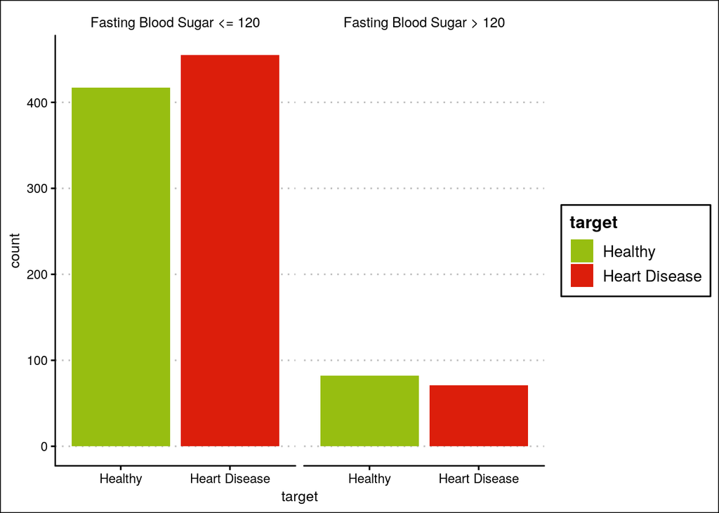

```r
ggplot(heartDiseaseData,aes(target, fill=target)) +
  geom_bar(stat="count") +
  facet_wrap(~fbs, ncol=2,scale="fixed") +
  theme_clean() +
  scale_fill_manual(values=c("#97BE11","#DC1E0B"))
```

People having Rest ECG-1 have a higher probability of suffering from heart diseases

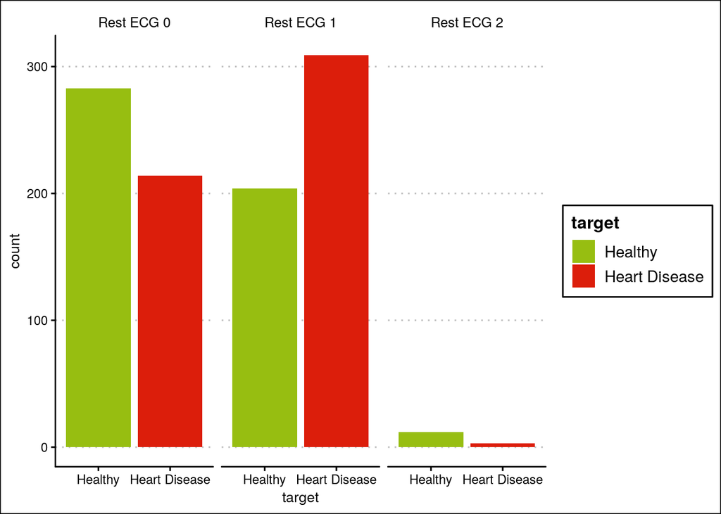

```r
ggplot(heartDiseaseData,aes(target, fill=target)) +
  geom_bar(stat="count") +
  facet_wrap(~restecg, ncol=3,scale="fixed") +
  theme_clean() +
  scale_fill_manual(values=c("#97BE11","#DC1E0B"))
```

People with No exercise induced angina have a higher probability of getting heart diseases

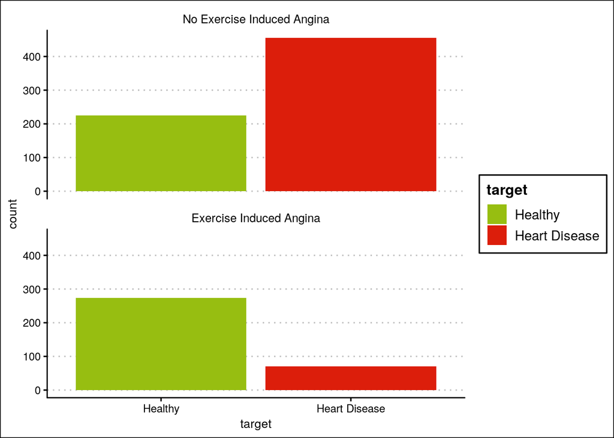

```r
ggplot(heartDiseaseData,aes(target, fill=target)) +
  geom_bar(stat="count") +
  facet_wrap(~exang, ncol=1,scale="fixed") +
  theme_clean() +
  scale_fill_manual(values=c("#97BE11","#DC1E0B"))
```

People with Peak Exercise slope 2 have a higher probability of exhibiting heart diseases

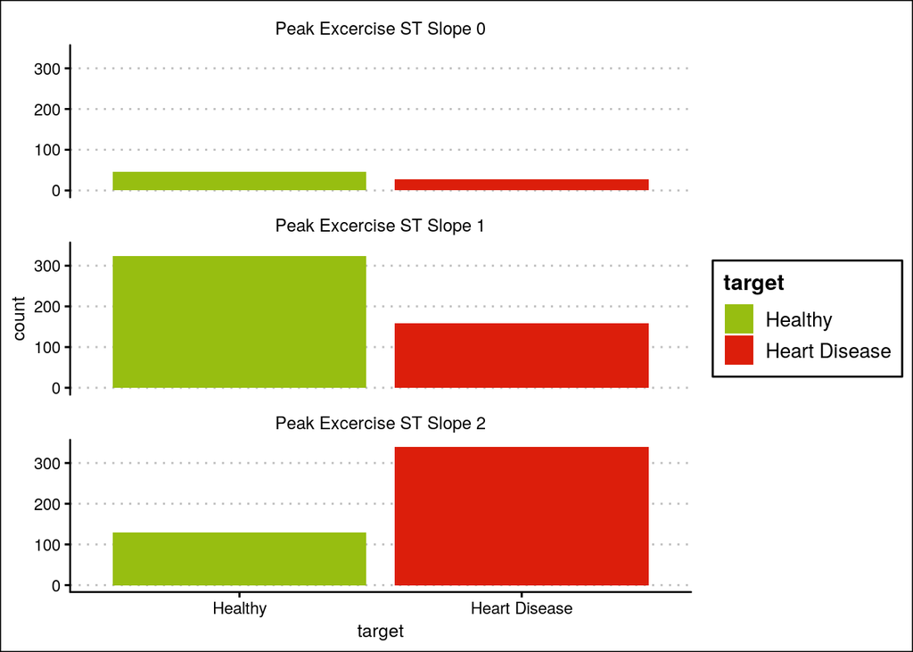

```r
ggplot(heartDiseaseData,aes(target, fill=target)) +
  geom_bar(stat="count") +
  facet_wrap(~slope, ncol=1,scale="fixed") +
  theme_clean() +
  scale_fill_manual(values=c("#97BE11","#DC1E0B"))
```

People with fixed defect Thalassemia have a higher probability to suffer from heart diseases

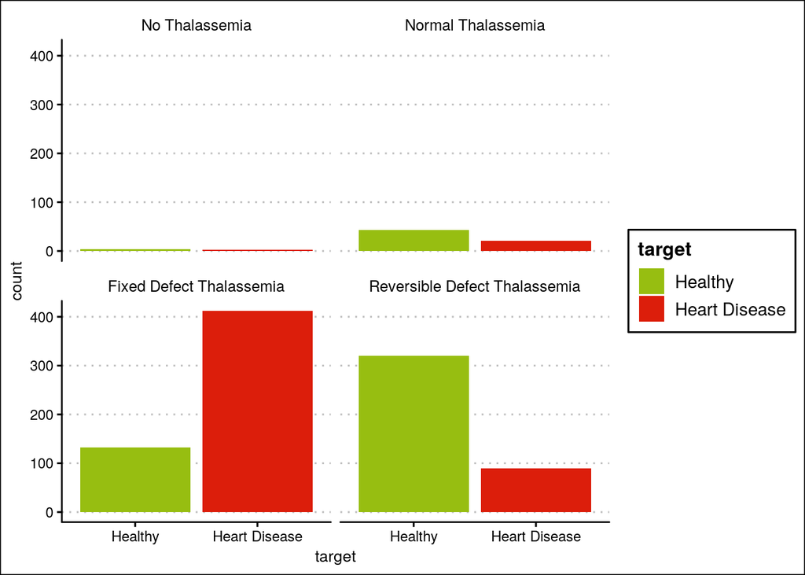

```r
ggplot(heartDiseaseData,aes(target, fill=target)) +
  geom_bar(stat="count") +
  facet_wrap(~thal, ncol=2,scale="fixed") +
  theme_clean() +
  scale_fill_manual(values=c("#97BE11","#DC1E0B"))
```

```r
log<-glm(target~., data=heartDiseaseData, family=binomial)
summary(log)
```

```
##
## Call:
## glm(formula = target ~ ., family = binomial, data = heartDiseaseData)
##
## Deviance Residuals:
##     Min       1Q   Median       3Q      Max
## -2.6847  -0.3666   0.1285   0.5176   2.6693
##
## Coefficients:
##                                    Estimate Std. Error z value Pr(>|z|)
## (Intercept)                        0.974938   1.843806   0.529 0.596969
## age                               -0.004314   0.012820  -0.337 0.736479
## sexMale                           -1.610703   0.283425  -5.683 1.32e-08
## cpChest Pain Type 1                1.061225   0.301235   3.523 0.000427
## cpChest Pain Type 2                1.963836   0.257085   7.639 2.19e-14
## cpChest Pain Type 3                1.989568   0.352181   5.649 1.61e-08
## trestbps                          -0.014901   0.005819  -2.561 0.010443
## chol                              -0.005541   0.002130  -2.602 0.009277
## fbsFasting Blood Sugar > 120       0.048261   0.304550   0.158 0.874090
## restecgRest ECG 1                  0.511138   0.202653   2.522 0.011661
## restecgRest ECG 2                 -0.402546   1.224640  -0.329 0.742378
## thalach                            0.018227   0.005859   3.111 0.001865
## exangExercise Induced Angina      -0.751473   0.233353  -3.220 0.001280
## oldpeak                           -0.506650   0.122129  -4.148 3.35e-05
## slopePeak Excercise ST Slope 1    -0.540297   0.456438  -1.184 0.236522
## slopePeak Excercise ST Slope 2     0.269358   0.492490   0.547 0.584427
## ca                                -0.813103   0.109901  -7.399 1.38e-13
## thalNormal Thalassemia             1.918293   1.306918   1.468 0.142159
## thalFixed Defect Thalassemia       1.855539   1.263123   1.469 0.141831
## thalReversible Defect Thalassemia  0.523928   1.268851   0.413 0.679668
##
## (Intercept)
## age
## sexMale                           ***
## cpChest Pain Type 1               ***
## cpChest Pain Type 2               ***
## cpChest Pain Type 3               ***
## trestbps                          *
## chol                              **
## fbsFasting Blood Sugar > 120
## restecgRest ECG 1                 *
## restecgRest ECG 2
## thalach                           **
## exangExercise Induced Angina      **
## oldpeak                           ***
## slopePeak Excercise ST Slope 1
## slopePeak Excercise ST Slope 2
## ca                                ***
## thalNormal Thalassemia
## thalFixed Defect Thalassemia
## thalReversible Defect Thalassemia
## ---
## Signif. codes:  0 '***' 0.001 '**' 0.01 '*' 0.05 '.' 0.1 ' ' 1
##
## (Dispersion parameter for binomial family taken to be 1)
##
##     Null deviance: 1420.24  on 1024  degrees of freedom
## Residual deviance:  688.48  on 1005  degrees of freedom
## AIC: 728.48
##
## Number of Fisher Scoring iterations: 6
```

Summary of the significant features

```r
d<-heartDiseaseData[,c(2,3,9,10,12,14)]
summary(d)
```

```
##      sex                      cp                             exang
##  Female:312   Chest Pain Type 0:497   No Exercise Induced Angina:680
##  Male  :713   Chest Pain Type 1:167   Exercise Induced Angina   :345
##               Chest Pain Type 2:284
##               Chest Pain Type 3: 77
##
##
##     oldpeak            ca                   target
##  Min.   :0.000   Min.   :0.0000   Healthy      :499
##  1st Qu.:0.000   1st Qu.:0.0000   Heart Disease:526
##  Median :0.800   Median :0.0000
##  Mean   :1.072   Mean   :0.7541
##  3rd Qu.:1.800   3rd Qu.:1.0000
##  Max.   :6.200   Max.   :4.0000
```

Logistic Regression

```r
log<-glm(target~., data=d, family=binomial)
summary(log)
```

```
##
## Call:
## glm(formula = target ~ ., family = binomial, data = d)
##
## Deviance Residuals:
##     Min       1Q   Median       3Q      Max
## -2.2611  -0.5287   0.1985   0.5618   2.5538
##
## Coefficients:
##                              Estimate Std. Error z value Pr(>|z|)
## (Intercept)                   1.83497    0.23512   7.804 5.98e-15 ***
## sexMale                      -1.44810    0.21159  -6.844 7.70e-12 ***
## cpChest Pain Type 1           1.37939    0.26083   5.289 1.23e-07 ***
## cpChest Pain Type 2           2.08254    0.22601   9.215  < 2e-16 ***
## cpChest Pain Type 3           1.95453    0.32787   5.961 2.50e-09 ***
## exangExercise Induced Angina -1.18874    0.20450  -5.813 6.14e-09 ***
## oldpeak                      -0.80667    0.09880  -8.165 3.22e-16 ***
## ca                           -0.73873    0.08973  -8.233  < 2e-16 ***
## ---
## Signif. codes:  0 '***' 0.001 '**' 0.01 '*' 0.05 '.' 0.1 ' ' 1
##
## (Dispersion parameter for binomial family taken to be 1)
##
##     Null deviance: 1420.24  on 1024  degrees of freedom
## Residual deviance:  811.27  on 1017  degrees of freedom
## AIC: 827.27
##
## Number of Fisher Scoring iterations: 5
```

```r
log.df<-tidy(log)
```

Observations portray that if an individual has the chest pain of type-2 or 3, there is a higher chances of heart diseases. Higher the value of number of blood vessels, exercise induced angina, st-depression and sex male, lower are the chances of heart diseases.

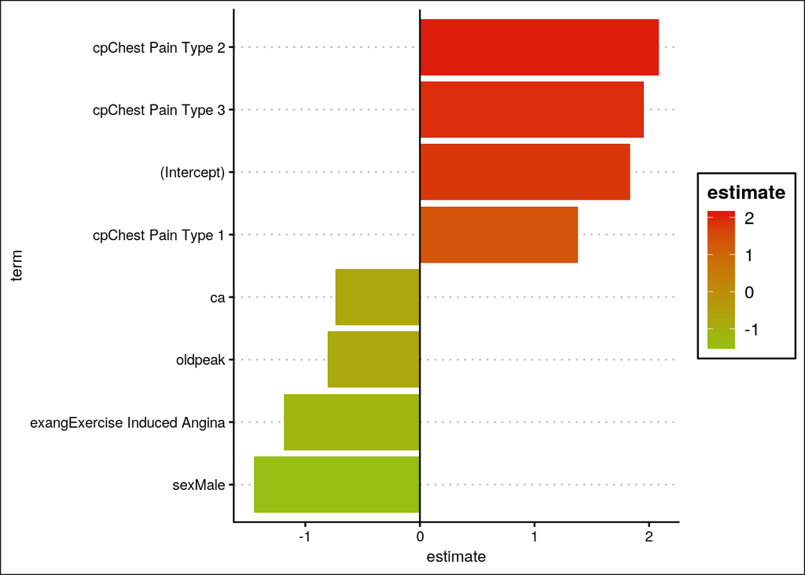

```r
log.df %>%
  mutate(term=reorder(term,estimate)) %>%
  ggplot( aes(term,estimate, fill=estimate)) +
  geom_bar(stat="identity") +
  scale_fill_gradient(low = "#97BE11",high = "#DC1E0B") +
  theme_clean() +
  geom_hline(yintercept=0) +
  coord_flip()
```

As the value of oldpeak –> ST depression increases, the probability of heart disease decreases As the number of blood vessels rises, the probability of heart disease in females decreses, while it increases for males Logistic Regression

```r
data<-d
set.seed(1237)
train <- sample(nrow(data), .8*nrow(data), replace = FALSE)
TrainSet <- data[train,]
ValidSet <- data[-train,]

#Tuning parameters
fitControl <- trainControl(method = "repeatedcv",
                           number = 10,
                           repeats = 10,
                           classProbs = TRUE,
                           summaryFunction = twoClassSummary)



TrainSet$target<-make.names(TrainSet$target)
set.seed(142)
TrainSet$target<-as.factor(TrainSet$target)
```

```r
gbm.ada.1 <- caret::train(target ~ .,
                                      data = TrainSet ,
                                      method = "glm",
                                      trControl = fitControl,
                                      metric="ROC")

gbm.ada.1
```

```
## Generalized Linear Model
##
## 820 samples
##   5 predictor
##   2 classes: 'Healthy', 'Heart.Disease'
##
## No pre-processing
## Resampling: Cross-Validated (10 fold, repeated 10 times)
## Summary of sample sizes: 738, 738, 737, 738, 738, 738, ...
## Resampling results:
##
##   ROC        Sens       Spec
##   0.9031278  0.8220577  0.8476024
```

```r
varImp(gbm.ada.1)
```

```
## glm variable importance
##
##                                Overall
## `cpChest Pain Type 2`           100.00
## oldpeak                          92.00
## ca                               64.84
## sexMale                          63.22
## `cpChest Pain Type 3`            20.26
## `cpChest Pain Type 1`            10.43
## `exangExercise Induced Angina`    0.00
```

```r
pred <- predict(gbm.ada.1,ValidSet)
levels(pred)[2] <- "Heart Disease"
t<-table(pred, ValidSet$target)
t.df<-as.data.frame(t)

res<-caret::confusionMatrix(t, positive="Heart Disease")
res
```

```
## Confusion Matrix and Statistics
##
##
## pred            Healthy Heart Disease
##   Healthy            72            16
##   Heart Disease      28            89
##
##                Accuracy : 0.7854
##                  95% CI : (0.7228, 0.8395)
##     No Information Rate : 0.5122
##     P-Value [Acc > NIR] : 5.96e-16
##
##                   Kappa : 0.5692
##
##  Mcnemar's Test P-Value : 0.09725
##
##             Sensitivity : 0.8476
##             Specificity : 0.7200
##          Pos Pred Value : 0.7607
##          Neg Pred Value : 0.8182
##              Prevalence : 0.5122
##          Detection Rate : 0.4341
##    Detection Prevalence : 0.5707
##       Balanced Accuracy : 0.7838
##
##        'Positive' Class : Heart Disease
##
```

Confusion Matrix

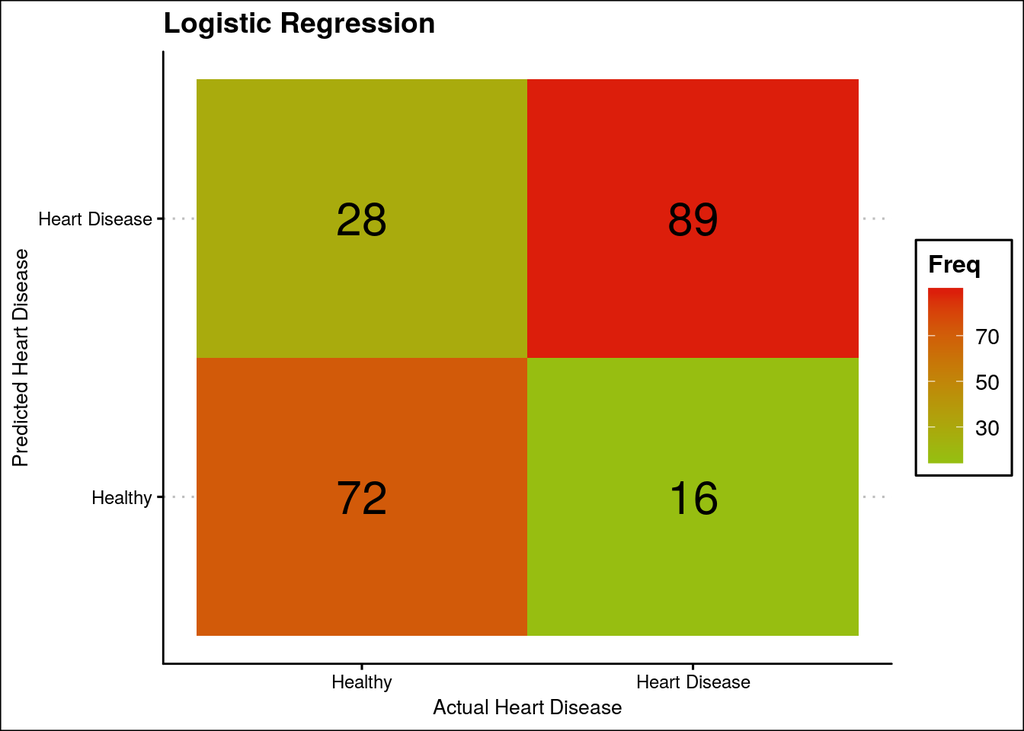

```r
ggplot(data = t.df, aes(x = Var2, y = pred, label=Freq)) +
  geom_tile(aes(fill = Freq)) +
  scale_fill_gradient(low="#97BE11",high="#DC1E0B") +
  theme_clean() +
  xlab("Actual Heart Disease") +
  ylab("Predicted Heart Disease") +
  geom_text(size=8) +
  ggtitle("Logistic Regression")
```

Random Forest

```r
gbm.ada.1 <- caret::train(target ~ .,
                                      data = TrainSet ,
                                      method = "rf",
                                      trControl = fitControl,
                                      metric="ROC")

gbm.ada.1
```

```
## Random Forest
##
## 820 samples
##   5 predictor
##   2 classes: 'Healthy', 'Heart.Disease'
##
## No pre-processing
## Resampling: Cross-Validated (10 fold, repeated 10 times)
## Summary of sample sizes: 737, 739, 738, 738, 738, 738, ...
## Resampling results across tuning parameters:
##
##   mtry  ROC        Sens       Spec
##   2     0.9514831  0.8364295  0.9482171
##   4     0.9683115  0.8927885  0.9508250
##   7     0.9721075  0.9165962  0.9451052
##
## ROC was used to select the optimal model using the largest value.
## The final value used for the model was mtry = 7.
```

Feature Importance

```r
varImp(gbm.ada.1)
```

```
## rf variable importance
##
##                              Overall
## oldpeak                      100.000
## ca                            62.815
## exangExercise Induced Angina  28.875
## sexMale                       15.453
## cpChest Pain Type 2           12.702
## cpChest Pain Type 3            3.989
## cpChest Pain Type 1            0.000
```

```r
pred <- predict(gbm.ada.1,ValidSet)
levels(pred)[2] <- "Heart Disease"
t<-table(ValidSet$target, pred)
t.df<-as.data.frame(t)
res<-caret::confusionMatrix(t, positive="Heart Disease")
res
```

```
## Confusion Matrix and Statistics
##
##                pred
##                 Healthy Heart Disease
##   Healthy            83            17
##   Heart Disease       4           101
##
##                Accuracy : 0.8976
##                  95% CI : (0.8477, 0.9355)
##     No Information Rate : 0.5756
##     P-Value [Acc > NIR] : < 2.2e-16
##
##                   Kappa : 0.7944
##
##  Mcnemar's Test P-Value : 0.008829
##
##             Sensitivity : 0.8559
##             Specificity : 0.9540
##          Pos Pred Value : 0.9619
##          Neg Pred Value : 0.8300
##              Prevalence : 0.5756
##          Detection Rate : 0.4927
##    Detection Prevalence : 0.5122
##       Balanced Accuracy : 0.9050
##
##        'Positive' Class : Heart Disease
##
```

Confusion Matrix

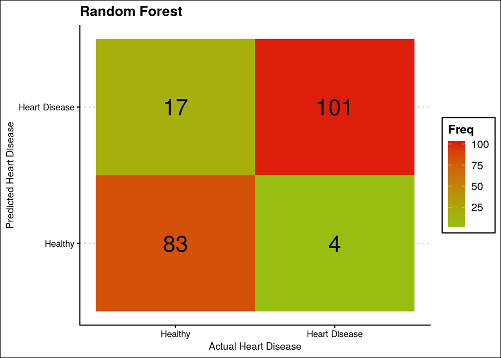

```r
ggplot(data = t.df, aes(x = Var1, y = pred, label=Freq)) +
  geom_tile(aes(fill = Freq)) +
  scale_fill_gradient(low = "#97BE11",high = "#DC1E0B") +
  theme_clean() +
  xlab("Actual Heart Disease") +
  ylab("Predicted Heart Disease") +
  geom_text(size=8) +
  ggtitle("Random Forest")
```

Plotting Decision Tree

```r
gbmGrid <-  expand.grid(cp=c(0.01))
fitControl <- trainControl(method = "repeatedcv",
                           number = 10,
                           repeats = 10,
                           classProbs = TRUE,
                           summaryFunction = twoClassSummary)
d$target<-make.names(d$target)
system.time(gbm.ada.1 <- caret::train(target ~ .,
                                      data = d ,
                                      method = "rpart",
                                      trControl = fitControl,
                                      metric="ROC",
                                      tuneGrid=gbmGrid))
```

```
##    user  system elapsed
##   3.134   0.008   1.902
```

```r
gbm.ada.1
```

```
## CART
##
## 1025 samples
##    5 predictor
##    2 classes: 'Healthy', 'Heart.Disease'
##
## No pre-processing
## Resampling: Cross-Validated (10 fold, repeated 10 times)
## Summary of sample sizes: 922, 923, 923, 922, 922, 923, ...
## Resampling results:
##
##   ROC        Sens       Spec
##   0.8667657  0.8119347  0.8746045
##
## Tuning parameter 'cp' was held constant at a value of 0.01
```

```r
varImp(gbm.ada.1)
```

```
## rpart variable importance
##
##                                 Overall
## oldpeak                        100.0000
## exangExercise Induced Angina    85.3950
## cpChest Pain Type 2             67.5191
## ca                              63.1697
## sexMale                         48.8267
## cpChest Pain Type 1              7.4876
## cpChest Pain Type 3              0.5601
## `exangExercise Induced Angina`   0.0000
## `cpChest Pain Type 1`            0.0000
## `cpChest Pain Type 2`            0.0000
## `cpChest Pain Type 3`            0.0000
```

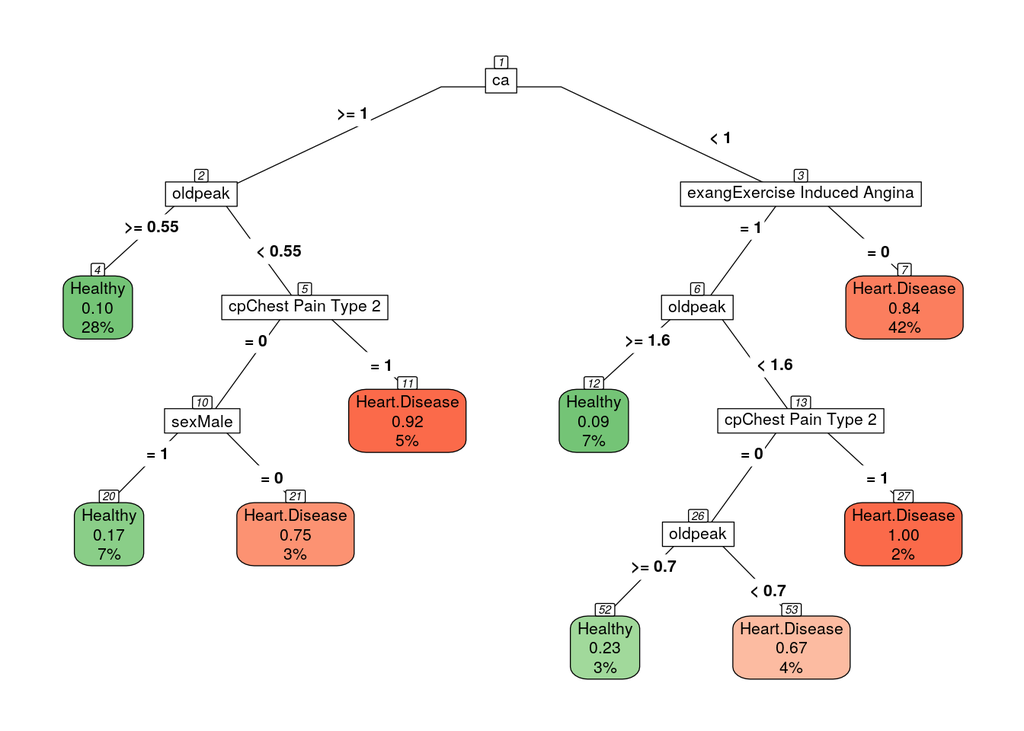

```r
rpart.plot(gbm.ada.1$finalModel,
           type=5,
           fallen.leaves = FALSE,
           box.palette = "GnRd",
           nn=TRUE)
```

Neural Network

```r
fitControl <- trainControl(method = "repeatedcv",
                           number = 10,
                           repeats = 10,
                           classProbs = TRUE,
                           summaryFunction = twoClassSummary)
gbm.ada.1 <- caret::train(target ~ .,
                                      data = TrainSet ,
                                      method = "nnet",
                                      trControl = fitControl,
                                      metric="ROC")
gbm.ada.1
```

```
## Neural Network
##
## 820 samples
##   5 predictor
##   2 classes: 'Healthy', 'Heart.Disease'
##
## No pre-processing
## Resampling: Cross-Validated (10 fold, repeated 10 times)
## Summary of sample sizes: 738, 737, 738, 738, 738, 738, ...
## Resampling results across tuning parameters:
##
##   size  decay  ROC        Sens       Spec
##   1     0e+00  0.8873818  0.8132885  0.8572924
##   1     1e-04  0.8895341  0.8168397  0.8482558
##   1     1e-01  0.9033646  0.8035513  0.8829125
##   3     0e+00  0.9230757  0.8234679  0.8842968
##   3     1e-04  0.9250854  0.8213462  0.8910022
##   3     1e-01  0.9260744  0.8118333  0.8875969
##   5     0e+00  0.9439748  0.8430385  0.9009468
##   5     1e-04  0.9469135  0.8465897  0.8994574
##   5     1e-01  0.9380939  0.8305321  0.8952215
##
## ROC was used to select the optimal model using the largest value.
## The final values used for the model were size = 5 and decay = 1e-04.
```

Variable importance

```r
varImp(gbm.ada.1)
```

```
## nnet variable importance
##
##                              Overall
## sexMale                       100.00
## exangExercise Induced Angina   92.05
## ca                             78.23
## oldpeak                        53.44
## cpChest Pain Type 3            26.27
## cpChest Pain Type 2            22.55
## cpChest Pain Type 1             0.00
```

```r
pred <- predict(gbm.ada.1,ValidSet)
levels(pred)[2] <- "Heart Disease"
t<-table(ValidSet$target, pred)
t.df<-as.data.frame(t)
res<-caret::confusionMatrix(t, positive="Heart Disease")
res
```

```
## Confusion Matrix and Statistics
##
##                pred
##                 Healthy Heart Disease
##   Healthy            69            31
##   Heart Disease       8            97
##
##                Accuracy : 0.8098
##                  95% CI : (0.7492, 0.8611)
##     No Information Rate : 0.6244
##     P-Value [Acc > NIR] : 6.903e-09
##
##                   Kappa : 0.6172
##
##  Mcnemar's Test P-Value : 0.000427
##
##             Sensitivity : 0.7578
##             Specificity : 0.8961
##          Pos Pred Value : 0.9238
##          Neg Pred Value : 0.6900
##              Prevalence : 0.6244
##          Detection Rate : 0.4732
##    Detection Prevalence : 0.5122
##       Balanced Accuracy : 0.8270
##
##        'Positive' Class : Heart Disease
##
```

Confusion Matrix

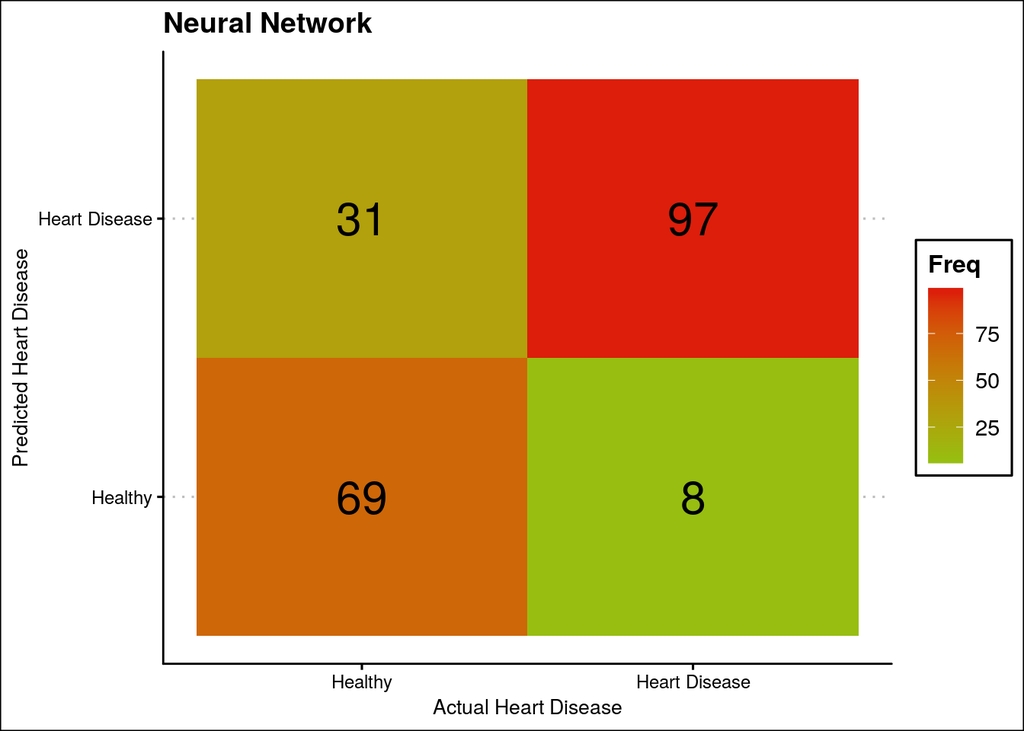

```r
ggplot(data = t.df, aes(x = Var1, y = pred, label=Freq)) +
  geom_tile(aes(fill = Freq)) +
  scale_fill_gradient(low = "#97BE11",high = "#DC1E0B") +
  theme_clean() +
  xlab("Actual Heart Disease") +
  ylab("Predicted Heart Disease") +
  geom_text(size=8) +
  ggtitle("Neural Network")
```